# Environmental Niche Modelling in R

Jack Richardson u7291420

4/10/23

# Word/figure count

# Location on GitHub

https://github.com/JackRicho/DS4B-final-project

# Introduction

## What is ENM?

ENM (Environmental Niche Modeling), commonly referred to as Species Distribution Modelling (SDM) is the use of computational models to calculate habitat suitability for a particular species, and thus where they may be found.

There are a variety of approaches a model can take I have selected to use BioClim, which inputs geographic observation data of platypus, then finds key relations of presence and absence with a number of climatic variables [Booth et.al, 2013]. The model then gives each square on a grid map of Australia a score, whereby which higher values indicate more suitable conditions, and lower values represent less suitable conditions.

BioClim is not the only approach to SDM. More complex methods, such as Generalized Linear Modelling, and less complex methods, such as Domain, are available. Additionally, alternative approaches exist, like Random Forests, which is based on decision trees rather than observation data, making it, in theory, possible to model species of which limited observations exist, such as introduced species.

For this project, BioClim is the most appropriate option, as it is designed not to predict places of new sightings, but to calculate the relative suitability of habitats, assisting in identifying areas of likely observation.

## Why Platypus?

Platypus are nocturnal aquatic mammals (monotremes) that spend large amounts of time within burrows accessible only underground and underwater [Biano et. al, 2019]. As such, the best time to see them is nearly exclusively at night (or early mornings and late evenings in winter). To add to this, they are beautiful creatures and some of the most morphologically unique on the world. It has been my project for the year to spot one in the wild, and ENM can help do so.

# Data Description

Bioclimatic environment data that represents annual trends in climate, rainfall and seasonalty. Standard set of variables used in Species Distribution Modeling

Rivers Dataset containing geospatial point locations of Australia and New Zealand Rivers derived from World Wildlife Fund’s (WWF) HydroSHEDS drainage direction layer and a stream network layer.

# Questions/Aims

This project has 2 aims:

- Primary Aim: To create a species distribution model of Platypus using the bioclim model.
- Secondary Aim: To create a tool whereby users can input a location and they are told the suitability of that place to platypus habitation, and are told a nearby river where they may be able to find platypus

```r
library(sf)
library(rgdal)
library(dplyr)
library(devtools)
library(ENMTools)
library(tidyverse)
library(leaflet)
library(terra)
library(rnaturalearth)
```

# Raw data

## Platypus Observation Data

Platypus Data: Available through Atlas of Living Australia. Search: *Ornithorhynchus anatinus*

available here: https://bie.ala.org.au/species/https://biodiversity.org.au/afd/taxa/ac61fd14-4950-4566-b384-304bd99ca75f

acquired 18-10-2023 with no data exclusions. Renamed (Speciescommonname)DD-MM-YY i.e. Platypus18-10-23

## Rivers of Australia & NZ Data

Rivers Data: Available through Food and Agriculture Organization of the United Nations: /AQUASTAT/Rivers of Australia and New Zealand In ERSI data format (geospatial data)

available here: https://data.apps.fao.org/catalog/iso/6a53d768-1e20-46ea-92a8-c4040286057d

## Environmental Variables and BioClim Raster Data

Environment Data: Environment data available through raster package

```r
# Get Environment Data
env <- raster::getData(name = "worldclim", res = 10, var = "bio")
```

# Data wrangling

## Rivers Data

Data cleaning can be found on the github linked at the top, or here: [https://github.com/JackRicho/DS4B-final-project/blob/main/data_cleaning.html]

From its raw form, the rivers dataset was extracted so that each point separated from its list and associated with river name.

```r
SortedRivers <- read.csv("processed_data/SortedRivers.csv")
```

## Platypus Data

Data was cleaned to remove high location uncertainty values, duplicate entries, and absence records.

```r
platypus <- read.csv("processed_data/platypus.csv")
```

## Wrangling Environmental Variable Data

Environmental data

```r
# Trim down the environmental layer to frame data better, include Australia only
env <- crop(env, extent(110, 155, -45, -8))

bioclimVariables <- read.csv("processed_data/bioclimVariables.csv")

print(bioclimVariables)
```

```
##     X   BIO                                                               Name
## 1   1  BIO1                                    Annual Mean Temperature (C*100)
## 2   2  BIO2 Mean Diurnal Range (Mean of monthly (max temp - min temp)) (C*100)
## 3   3  BIO3                                   Isothermality (BIO2/BIO7) (×100)
## 4   4  BIO4                  Temperature Seasonality (standard deviation ×100)
## 5   5  BIO5                           Max Temperature of Warmest Month (C*100)
## 6   6  BIO6                           Min Temperature of Coldest Month (C*100)
## 7   7  BIO7                       Temperature Annual Range (BIO5-BIO6) (C*100)
## 8   8  BIO8                        Mean Temperature of Wettest Quarter (C*100)
## 9   9  BIO9                         Mean Temperature of Driest Quarter (C*100)
## 10 10 BIO10                        Mean Temperature of Warmest Quarter (C*100)
## 11 11 BIO11                        Mean Temperature of Coldest Quarter (C*100)
## 12 12 BIO12                                          Annual Precipitation (mm)
## 13 13 BIO13                                Precipitation of Wettest Month (mm)
## 14 14 BIO14                                 Precipitation of Driest Month (mm)
## 15 15 BIO15          Precipitation Seasonality (Coefficient of Variation) (mm)
## 16 16 BIO16                              Precipitation of Wettest Quarter (mm)
## 17 17 BIO17                               Precipitation of Driest Quarter (mm)
## 18 18 BIO18                              Precipitation of Warmest Quarter (mm)
## 19 19 BIO19                              Precipitation of Coldest Quarter (mm)
```

# Sanity checks

## Environment Sanity Checks

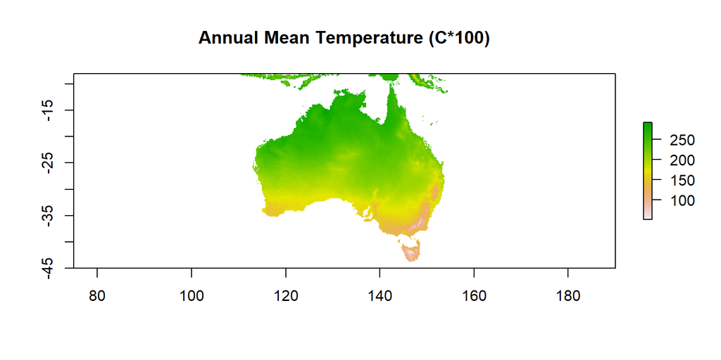

```r
# Check Environment Data
plot(env[[1]], main = bioclimVariables$Name[1])
```

```r
  # Framing is appropriate
```

## Platypus Sanity Checks

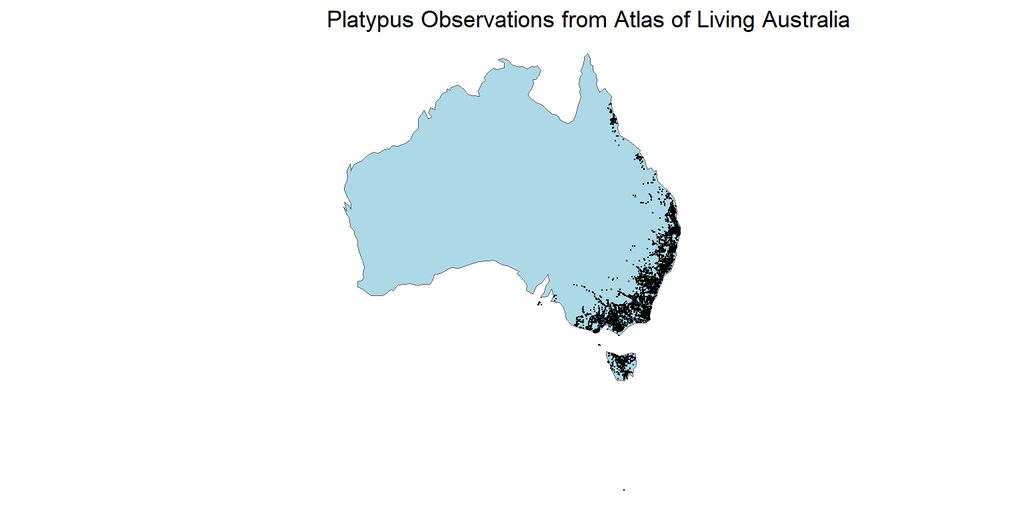

```r
# Use naturalEarth library to give a map outline of Australia
australia <- ne_countries(country = "Australia", returnclass = "sf")

# Create blank map of Australia
map <- ggplot() +
  geom_sf(data = australia, fill = "lightblue") +
  theme_void()

# Plot our platypus observations onto NaturalEarth map
map_with_points <- map +
  geom_point(data = platypus, aes(x = decimalLongitude, y = decimalLatitude), size = 0.1) +
  ggtitle("Platypus Observations from Atlas of Living Australia")

print(map_with_points)
```

## River Coordinate Point Extraction & Sanity Checks

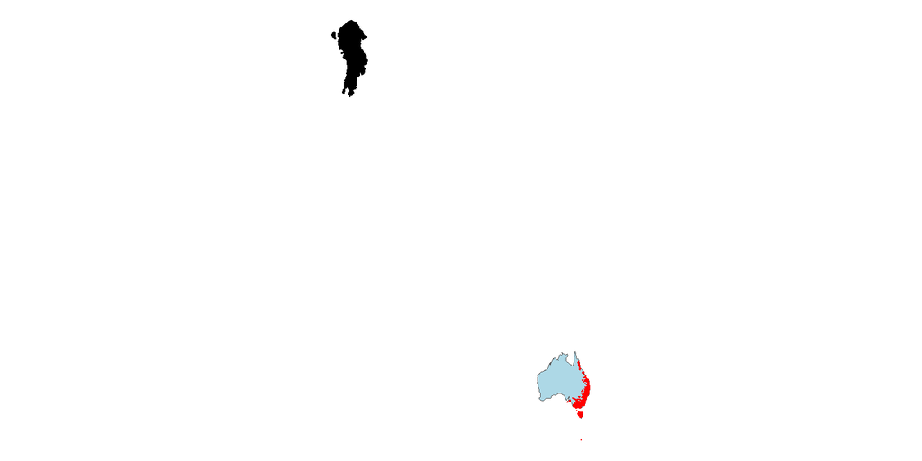

```r
# Plot points to ensure large amount of rivers in Australia contained within dataset
# And overlay platypus sightings to ensure most areas are located close to river

# Reuse NaturalEarth map
rivers_map_with_points <- map +
  geom_point(data = SortedRivers, aes(x = decimalLongitude, y = decimalLatitude), size = 0.1) +
  geom_point(data = platypus, aes(x = decimalLongitude, y = decimalLatitude), size = 0.1, colour = 'red')

print(rivers_map_with_points)
```

Red points are observed platypus sightings from Atlas of Living Australua. Black points are coordinates along the rivers.

# Addressing the questions/aims

## Creating a bioclim model

```r
# Create DF with only required data
platypusPresenceDF <- platypus %>%
  dplyr::select(decimalLongitude, decimalLatitude)
  # I have attempted to create this in the SpatRaster format, however it encounters issues down the line. Will work fine


# We package each lineage up in an ENMtools species object
# Creates empty object with slots for various values
platypusENM <- enmtools.species()

#Inhabit columns with required data
platypusENM$species.name <- "Ornithorhynchus anatinus"
platypusENM$presence.points <- platypusPresenceDF

# Check format of the enmtools.species
platypusENM <- check.species(platypusENM)
  # Populates object with required missing data
```

## BioClim Model

```r
# Use enmTools to create a bioclim model
platypus.bc <- enmtools.bc(platypusENM, env, test.prop = 0.3)
```

```r
  # Bioclim uses the presence of observed instances and analyses them in relation to our 19 climatic variables to create a suitability plot
```

### Response Plots

Understanding Bioclim Plots:

The x axis represents the particular condition/variable, for example, Annual Mean Temperature.

Presence: Each plot tests the climatic variable in relation to the occurrence of platypus. When the red axis is high (close to 1), it represents a high presence of platypus occurring in said condition.

Background: When the green plot is closer to 1, it represents areas of Australia’s environment which fits the variable condition, but does not have a high presence of platypus. If the green plot is close to or at 0, it mean that Australia has no environments that fit this condition.

Suitability: The blue plot is our models prediction of finding platypus in this environment, when all other climatic conditions are held at their mean.

### Annual Mean Temperature (C*100)

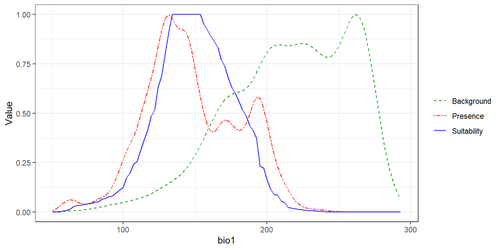

```r
platypus.bc$response.plots[1]
```

This plot is telling us that platypus are most likely to be found in environments where the annual mean temperature is below 20$^\circ$C, with an optimal temperature around 15$^\circ$C.

### Max Temperature of Warmest Month (C*100)

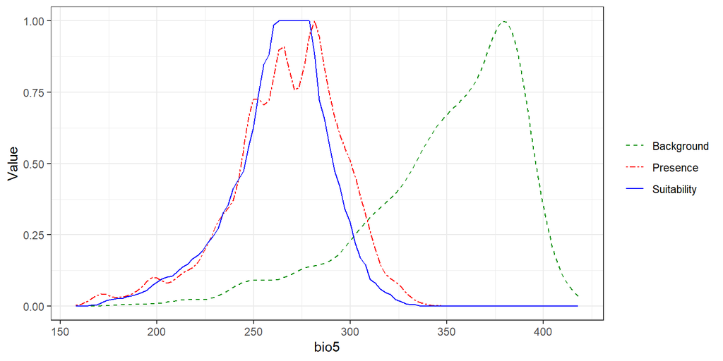

```r
platypus.bc$response.plots[5]
```

### Mean Temperature of Wettest Quarter (C*100)

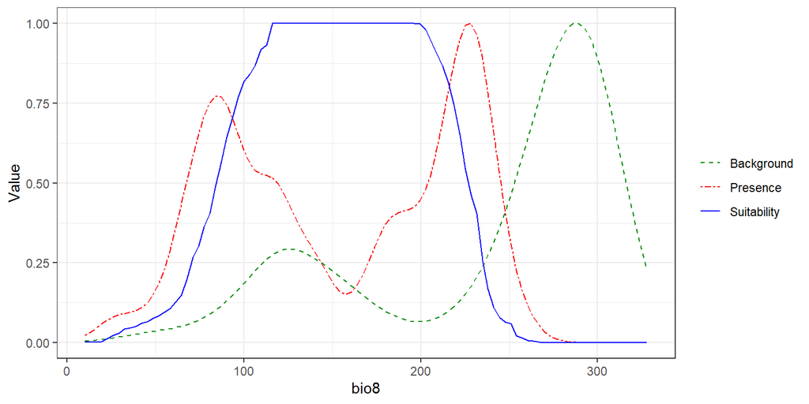

```r
platypus.bc$response.plots[8]
```

There are two important things to note here: There is little area of Australian environmental conditions in between these two groups, and there is a large area of environment with no platypus, and a much higher mean temperature during the wettest month.

What is going on here comes down to geography and precipiation. In the North (North QLD area) where monsoon conditions are present, the wettest quater of the year is around summer, which is also the hottest. Further south, in NSW and Vic, the wettest months of the year is around winter, which is much colder. Finally, the large platypus-absent hot area would be Australia’s arid, dry interior, which has its wettest months in summer.

This plot is useful in highlighting a flaw in the bioclim model. It is less complex than a model such as GLM (Generalized Linear Modelling), which may be able to account for the differing groups regardless, for the scope of this project, bioclim is the more appropriate due to its less complex and computationally challenging nature. [Warren, et.al, 2021]

### Other Observations

Platypus can withstand a decently wide range of climates, being found in Australia’s coldest environments (BIO1), but also in the warmer of regions of Queensland, all the way up to Cape York. Being aquatic, they are found commonly in climates with decent rainfall around all months [Hawke et.al, 2019]. Platypus are found more commonly in climates with less fluctuation in monthly temperatures (BIO3) and less temperature seasonality (BIO4).

### Interactive Map of BioClim Model

```r
# Create an interactive plot to view the model
interactive.plot.enmtools.model(platypus.bc)
```

[interactive chart not shown]

To see model, untick training points.

Lighter points represent areas with a higher environmental suitability for platypus habitation. The areas of habitation roughly follow the Great Dividing Range/East Coast, where platypus are more suited to the cooler, wetter east side of the mountian range.

Failings of the model: If we compare our model to the observations of platypus, we can see for example, that tasmania has seen many observations, but is ranked as relatively unsuitable by the model.

## Platypus Suitability Locator

Getting input to find platypus suitability

```r
# Current Location to assess platypus suitability
# Inputs require decimalLatLong
inputLatitude <- -35.272240
inputLongitude <- 149.121528
  # Current coordinates set to ANU

suitability_value <- extract(platypus.bc$suitability, cbind(inputLongitude, inputLatitude))
suitability_value <- as.numeric(suitability_value)

cat("Locations suitability value: ", suitability_value)
```

```
## Locations suitability value:  0.08478732
```

Of course, this is a model of a complex living organism, in an overwhelmingly complex living ecosystem. The model does not take into account human interference, such as daming, pollution, hunting, urbanisation and environmental destruction, all of which have been known to negatively impact platypus presence.

The best way to utelise the suitability function is through relative comparison. Try out a few locations, and have a look what the function determines is more suitable out of the options.

## Local River Finder

```r
# Current Location nearest river
# Using Haversine equation to find the nearest river:

# Function to calculate Haversine distance
nearestRiver <- function(lat1, lon1, lat2, lon2) {
  # Radius of the Earth in km
  earthRadius <- 6371

  # Convert degrees to radians
  lat1 <- lat1 * pi / 180
  lon1 <- lon1 * pi / 180
  lat2 <- lat2 * pi / 180
  lon2 <- lon2 * pi / 180

  # Haversine formula
  dlat <- lat2 - lat1
  dlon <- lon2 - lon1
  a <- sin(dlat/2)^2 + cos(lat1) * cos(lat2) * sin(dlon/2)^2
  c <- 2 * atan2(sqrt(a), sqrt(1-a))
  distance <- earthRadius * c

  return(distance)
}

# Calculate distances and find the nearest point
distances <- sapply(1:nrow(SortedRivers), function(i) {
  nearestRiver(inputLatitude, inputLongitude, SortedRivers$decimalLatitude[i], SortedRivers$decimalLongitude[i])
})

# Find the index of the minimum distance
nearest_point_index <- which.min(distances)

# Get the nearest point
nearest_point <- SortedRivers[nearest_point_index, ]

# Print the nearest point and distance
cat("Locations suitability value: ", suitability_value, "\n",
    "Local River:", nearest_point$SUB_NAME, "river", "\n",
    "Latitude:", nearest_point$decimalLatitude, "\n",
    "Longitude:", nearest_point$decimalLongitude, "\n",
    "Distance (in km) to River:", distances[nearest_point_index], "\n")
```

```
## Locations suitability value:  0.08478732
##  Local River: Richmond river
##  Latitude: 153.5771
##  Longitude: -28.87292
##  Distance (in km) to River: 6863.429
```

# References

- Booth, T.H., Nix, H.A., Busby, J.R. and Hutchinson, M.F. (2014), bioclim: the first species distribution modelling package, its early applications and relevance to most current MaxEnt studies. Diversity Distrib., 20: 1-9. https://doi.org/10.1111/ddi.12144
- Gilad Bino, Richard T Kingsford, Michael Archer, Joanne H Connolly, Jenna Day, Kimberly Dias, David Goldney, Jaime Gongora, , The platypus: evolutionary history, biology, and an uncertain future, Journal of Mammalogy, Volume 100, Issue 2, 24 April 2019, Pages 308–327, https://doi.org/10.1093/jmammal/gyz058
- Warren, D.L., Matzke, N.J., Cardillo, M., Baumgartner, J.B., Beaumont, L.J., Turelli, M., Glor, R.E., Huron, N.A., Simões, M., Iglesias, T.L., Piquet, J.C. and Dinnage, R. (2021), ENMTools 1.0: an R package for comparative ecological biogeography. Ecography, 44: 504-511. https://doi.org/10.1111/ecog.05485
- Tahneal Hawke, Gilad Bino, Richard T. Kingsford, A silent demise: Historical insights into population changes of the iconic platypus (Ornithorhynchus anatinus), Global Ecology and Conservation, Volume 20, 2019, ISSN 2351-9894, https://doi.org/10.1016/j.gecco.2019.e00720.